# Tertiary Education Expenditure: Macroeconomic and Social effects

Applied Data Science in the Field of Macroeconomics, Summester Semester 2024

Harry Paradice

2024

# 1 Introduction

Tertiary education is now delivered by institutions to keen students all across the globe. The structure, funding, and standards of these institutions and their pupils differ from country to country in part due to historical, economic, ideological and political factors. Suggested economic and social outcomes of tertiary education such as knowledge capital, GDP, wages, innovation, and improved health also differ between countries. These differences prompt the question, what effect does the structure of tertiary education have on such macroeconomic variables? In this report this question is investigated in relation to GDP, Income Inequality, and Happiness.

Education is often included in macroeconomic models through human or knowledge capital which, as a factor of production, increases the productivity of capital and increases aggregate output. It may also be described as a driver of innovation, causing improvements in technology and the creation of new markets. Education of course also has strong social and political applications, taking up large sections of government budgets and swaying voters. For these reasons, it is not surprising that government education expenditure was over 4% of the world’s GDP throughout the 2010s OECD (2023). However this spending has not been equally distributed throughout the world’s nations. The following figure shows the average number of years schooling attended by the population of each country as reported by the Human Development Index in 2018 Anon. The data for 2018 is used here as it was the most complete of recent years. Use the mouse curser to hover of the map to see the exact country values.

[interactive chart not shown]

The country with the highest mean years of education in 2022 was Germany with 14.3 years, followed by Switzerland, Canada, Iceland and the United States. The country with the lowest mean years of education was Niger with 1.3 years, followed by Mali, Somalia, Chad, and Burkina Faso. This map depicts the inequality in education attainment that still exists across the world. It is important for both economists and politicians to understand how the structure and funding of educational systems may affect the positive outcomes of education and employ this understanding to improve the effectiveness of education deliver. The county with the greatest improvement between 1990 and 2022 (where data was available for both years) was the United Arab Emirates with an increase 7.0 years (from 5.7 to 12.7), this was followed by Slovakia, Bahrain, Croatia and Malta. The following plot shows the trend over time for a selection of countries. The world average, as depicted by the **dashed black line**, increased from 5.9 years in 1990 to 8.9 in 2022. It is clear that although the number of years schooling for the world is increasing, some countries are still left behind, as seen by the only marginal improvements for countries such as Niger and Mali. It is of note however, that all but one country improved over this time period, Cote d’Ivoire decreased from 4.6 to 4.2 years over the time period.

[figure not shown]

These figures illustrate the current situation of educational attainment across all levels of education. It also highlights the importance of understanding the drivers of education. This sets a good context on which the rest of this report will build upon, through the investigation of education structuring and its effects. It should be made clear that this report focuses on tertiary education and not all levels of education. This is further defined in Section 3.

# 2 Data

## 2.1 OECD Education at a Glance 2023

The workhorse data for this report is sourced from the report Education at a Glance 2023: OECD Indicators OECD (2023). The data is available on the OECD database under the indicator ‘Expenditure on educational institutions as a percentage of GDP’ and contains the following summary:

> “This dataset contains data on expenditure on educational institutions as a percentage of GDP. The default table displays expenditure for the general government, the private sector and non-domestic sources, for the combined primary to tertiary levels of education, and for all public and private educational institutions. This can be changed to display data by: level of education, and type of educational institution.”

The data was extracted with the following filters applied:

**Table 1**: OECD Data: Expenditure on educational institutions as a percentage of GDP

| Filter | Selection |
| --- | --- |
| Time period | all; 1995-2021 |
| Reference area | all; 52 countries |
| Education level | Tertiary education |
| Financing source | all; general gov, private, RoW |
| Destination of expenditure | all; educational institutions |

## 2.2 UN Development Reports

For the visualisation of mean years schooling in the Introduction section, the data was sourced from the Human Development Index produced by the UN Anon. The Human Development Reports, produced by the Human Development Report Office for the UN Development Programme (UNDP), aims to capture and highlight key performance metrics of the planet and the progress of both nations and the world. The ‘All composite indices and components time series (1990-2022)’ link was used.

## 2.3 World Development Indicators

GDP and GDP per capita data for the years 1990 through 2023 were also accessed through the WDI package in Rmarkdown Arel-Bundock (2022). Specifically ‘NY.GDP.MKTP.CD’ and ‘NY.GDP.PCAP.CD’. Data was filtered by year accordingly.

## 2.4 OECD Income Inequality

Income inequality data was also sourced from the OECD database under the indicator ‘Income distribution database’ Anon. with the following summary:

> “The OECD Income Distribution Database (IDD) offers data on levels and trends in income inequality and poverty and is updated on a rolling basis, two to three times a year.”

The data was extracted with the following filters applied:

**Table 2**: OECD Data: Income distribution database

| Filter | Selection |
| --- | --- |
| Time period | 1990 - 2022 |
| Reference area | all; 46 countries |
| Measure | Gini (disposable income) |
| Methodology | Income definition since 2012 |
| Definition | Current definition |

## 2.5 World Happiness Report

Data on the happiness score of each country was sourced through the World Happiness Report Helliwell et al. (2024). The report calculates the rankings based on answers to a life evaluation question in the Gallup World Poll which had over 100,000 participants from 130 countries. The question asks respondents to consider a ladder where the best possible life would be a 10 and the worst to be a 0. The respondents then rate their own lives on this ladder. Figure 2.1 of the report for 2024 contains the happiness score for each country and this is available for download as ‘Data for Figure 2.1’.

## 2.6 Times Higher Education

Each year the Times Higher Education (THE) publishes a report on the top universities in the world Anon. (2023). The report ranks the universities by an overall score from 18 performance indicators across five of key metrics, specifically, teaching, research environment, research quality, industry and international outlook. In 2024 the ranking included 1,906 institutions in 108 countries. Data was sourced from an existing aggregated table of ranks across the years 2011 to 2024 Anon.

# 3 Education Funding Sources

## 3.1 Tertiary Education Classification

**Table 3**: Education levels and ISCED Classification REF: Education at a Glance 2023, OECD

| OECD Definition | ISCED Classification |
| --- | --- |
| *Primary education*: Designed to provide a sound basic education in reading, writing and mathematics and a basic understanding of some other subjects. Entry age: between 5 and 7. Typical duration: six… | ISCED 1 |
| *Lower secondary education*: Completes provision of basic education, usually in a more subject-oriented way with more specialist teachers. Programmes may differ by orientation, general or vocational, … | ISCED 2 |
| *Upper secondary education*: Stronger specialisation than at lower secondary level. Programmes offered are differentiated by orientation: general or vocational. Typical duration is three years. | ISCED 3 |
| *Post-secondary non-tertiary education*: Serves to broaden rather than deepen the knowledge, skills and competencies gained in upper secondary level. Programmes may be designed to increase options for… | ISCED 4 |
| *Short-cycle tertiary education*: Often designed to provide participants with professional knowledge, skills and competencies. Typically, they are practically based, occupation-specific and prepare st… | **ISCED 5** |
| *Bachelor’s or equivalent level*: Designed to provide participants with intermediate academic and/or professional knowledge, skills and competencies, leading to a first degree or equivalent qualificat… | **ISCED 6** |
| *Master’s or equivalent level*: Stronger specialisation and more complex content than bachelor’s level. Designed to provide participants with advanced academic and/or professional knowledge. May have … | **ISCED 7** |
| *Doctoral or equivalent level*: Designed to lead to an advanced research qualification. Programmes at this level are devoted to advanced study and original research, and exist in both academic and pro… | **ISCED 8** |

## 3.2 Fund Source Definition

Now that the definition of tertiary education has been achieved, the next challenge is to characterise the funding structures of tertiary education insitutions. It is difficult to characterise the funding structures due to differences in governance, reporting standards and nuances in legislation between countries and institutions. Broadly, tertiary education institutions can be funded through public funding (government expenditure) and/or tuition fees paid by students. It becomes quickly complex however when for example tuition fees paid by students are funded by government transfers given to students or when universities earn income through investment interest or patent licenses. Governments may also provide funding to private institutions to award grants to students or researchers, or distribute funds to other levels of government for administering. Differences in the autonomy of institutions also plays an important role. Are the university institutions publicly funded but act independently of the public sector or are they integrated in the cogs of the machinery of government? Again for this report, the solution is dependent on the definitions used in the collection of the source data. Three classes of tertiary education funding are defined as in ‘Education at a Glance 2023: OECD Indicators’ OECD (2023). There is ‘General government’, ‘Private sector (households and other non-educational private entities)’ and ‘Rest of world’. General government expenditure is all non-repayable capital transferred to tertiary institutions from all levels of government (e.g. national, state, & regional) as well as non-repayable transfers to students for tuition fees or student living costs. Private sector expenditure is all costs or grants paid by domestic private entities, primarily students and households through the payment of tuition fees and interest on student loads but also bursaries given by private companies or discounts for the supply of goods or services to education institutions. Rest of world is all funding from a non-domestic source, such as for research grants paid directly to the educational institutions or intergovernmental education aid. This factor is not so significant for tertiary education compared to domestic funding sources.

## 3.3 Inter-country comparisons

The following graph utilises the OECD Expenditure on Educational Institutions data and captures the amount countries spend on tertiary education as a percent of that country’s GDP.

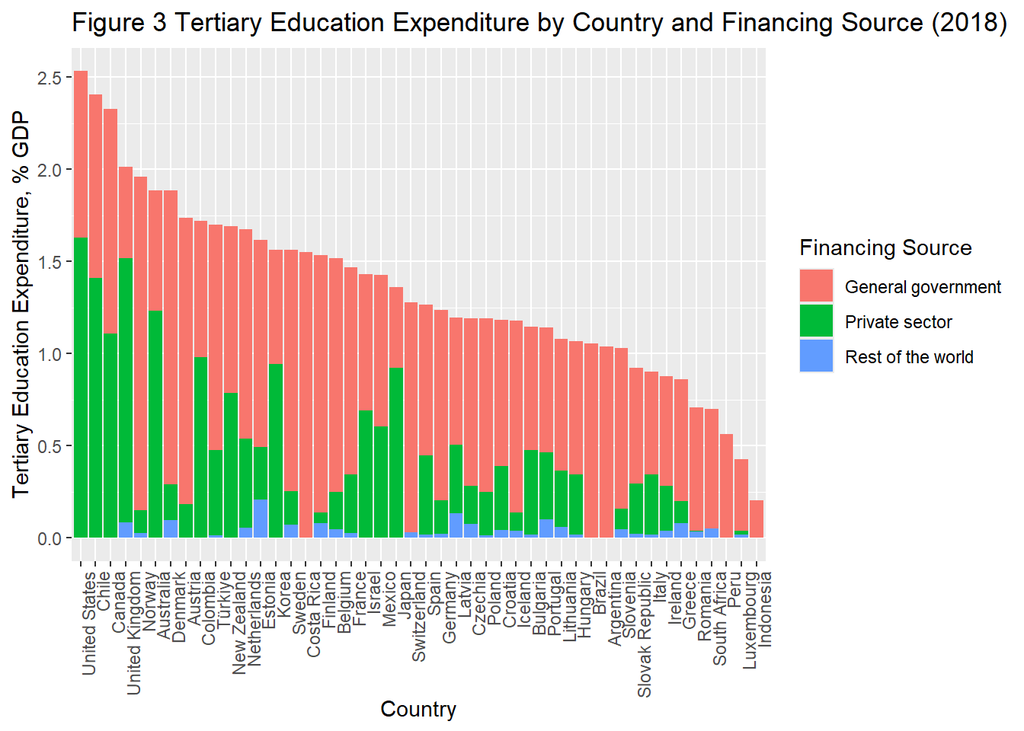

The mean expenditure for this data set is 1.3 % of GDP and the standard deviation is 0.48. It could be argued that the variation of the % of GDP spent on education is not large compared to that of the structure of this funding, as in seen in the following graph. It appears that the countries that spend the highest percentage of GDP on tertiary education also finance large portions of this through the private sector.

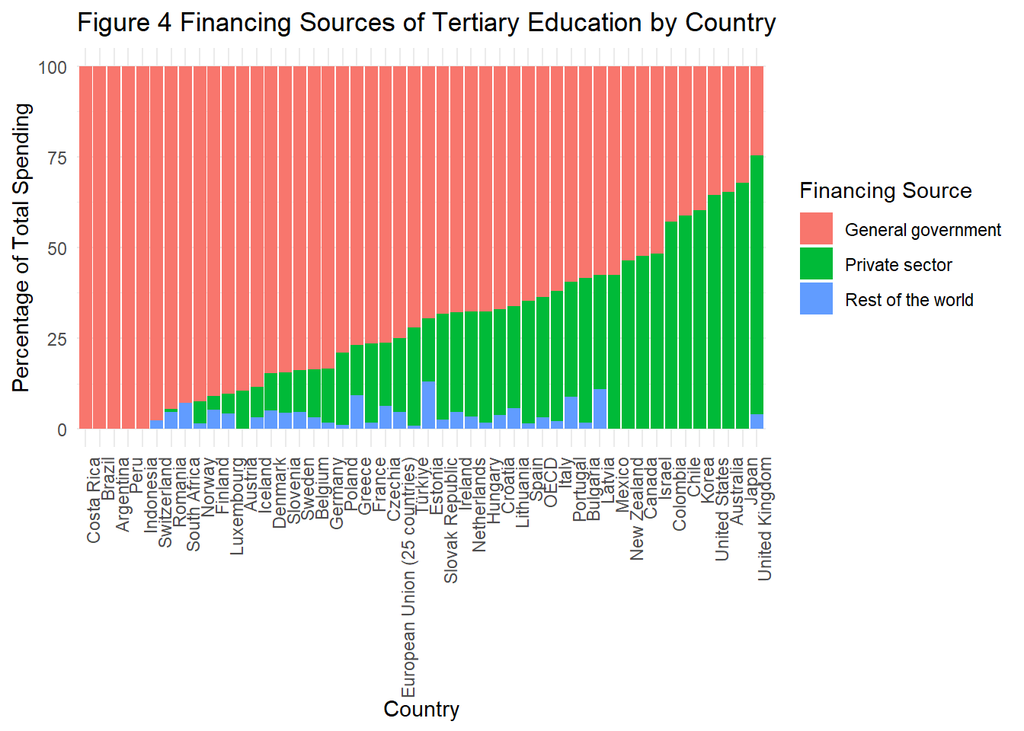

The data also suggests that there is minimal funding of tertiary education institutions from non-domestic sources. It is worth noting that international student tuition fees are considered domestic funding in this data as the students, in most cases, reside in the country of instruction.

# 4 Education Spending, Income and GDP

Is there a correlation between GDP per capita and the structure of tertiary education spending? As the GDP of a country increases, the wealthier the nation becomes. In theory, this would allow the nation to increase spending on education. As the marginal returns of other applications of capital decrease, the opportunity cost of education spending also decreases. This suggests that there should exist a correlation between GDP/GNI and the level of tertiary education spending. This correlation is evident in Figures 5 and 6 below. The question of causal linkage between these two variables is more difficult. GDP level likely influences immediate spending on education as budgets need to be set and financed, however in the long term a greater funding for education may increase GDP through improvements in the factor inputs of human and knowledge capital.

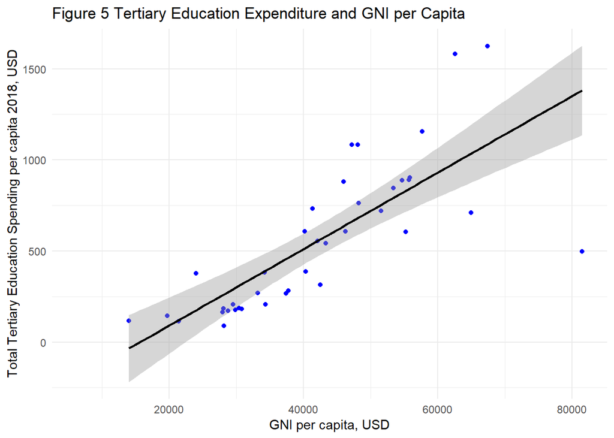

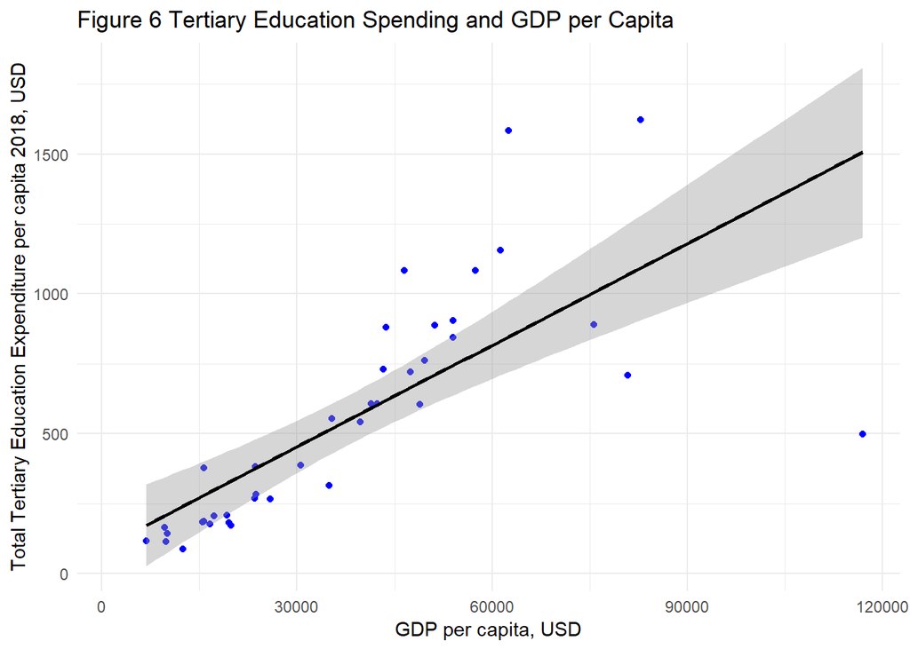

Both GDP and GNI have been included to establish a more rounded view of education spending and wealth. A significant difference between GDP and GNI may suggest that countries adjust education spending based on the source of wealth. While the direction of correlation is the same between both GNI and GDP, the slope of the linear model is lesser for GDP than for GNI (0.021 vs 0.012). This may suggest that changes in GDP per capita correspond to smaller changes in education spending compared to that of an equivalent change in GNI. This may suggest that education spending is more sensitive to foreign income earned than domestic income.

Now that we understand a correlation exists between education expenditure and GDP it will be informative to see whether the same correlation exists for the structure of education spending. One hypothesis could be that as as the GDP or income of a nation increases, the private sector will increase education spending in an effort to improve education quality beyond that provided by government spending, therefore increasing the ratio of private to public funding of tertiary institutions.

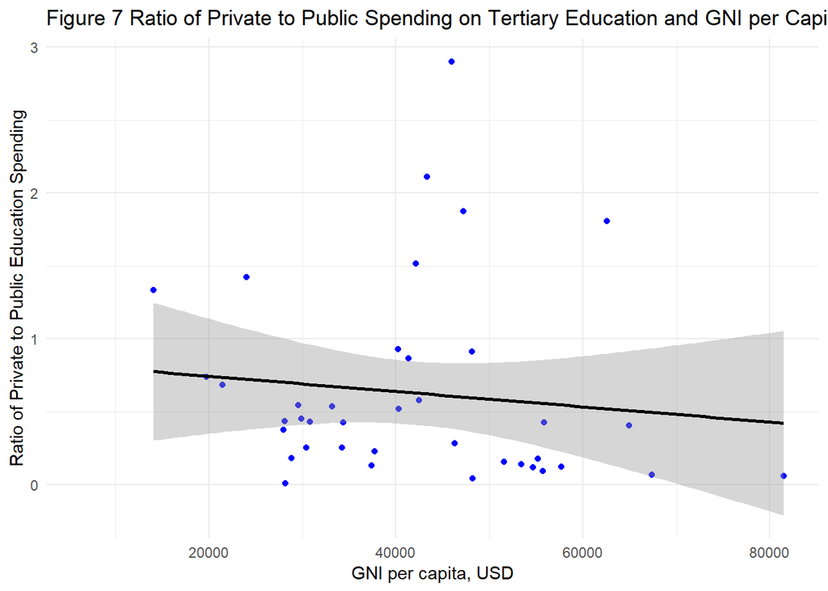

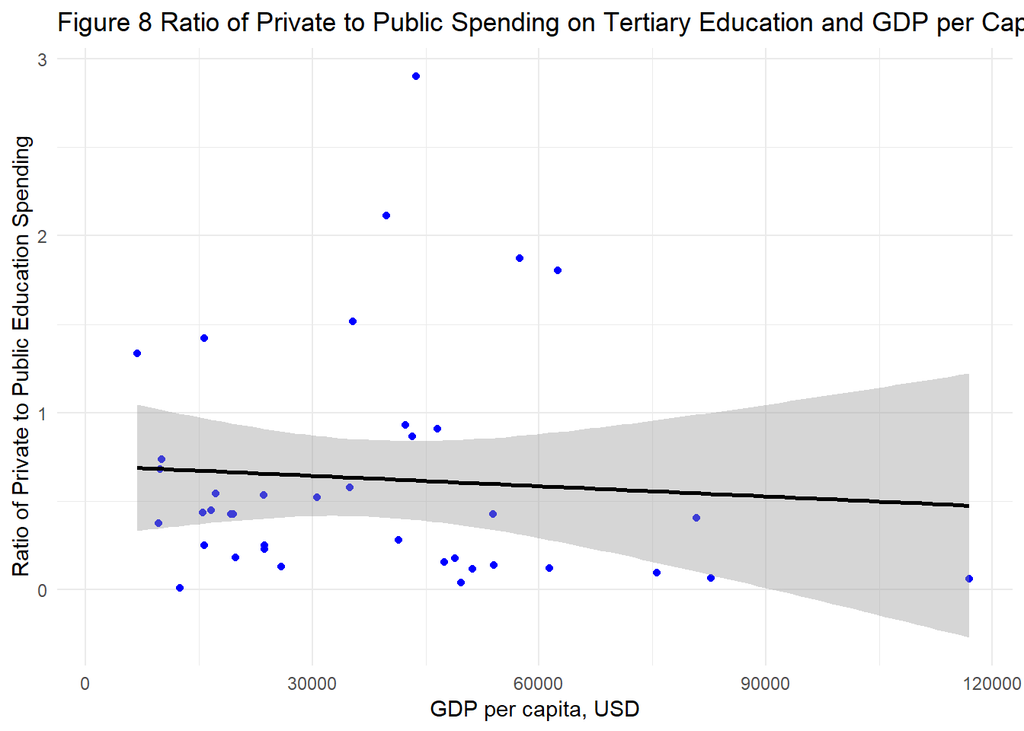

It can be seen from figures 7 and 8 however that there is no significant correlation between GDP or GNI and ratio of tertiary education spending between private entities and the general government. This may suggest that education funding decisions are made independently of a country’s economic wealth. The structure of funding may be dependent on other factors such as political decisions, societal values, or institutional requirements. A further investigation could be performed with a panel data regression of GDP and the private to public funding ratio over time however such an analysis is not included in this report. Inequality is however investigated with this method in the following section.

# 5 Inequality And Funding Sources

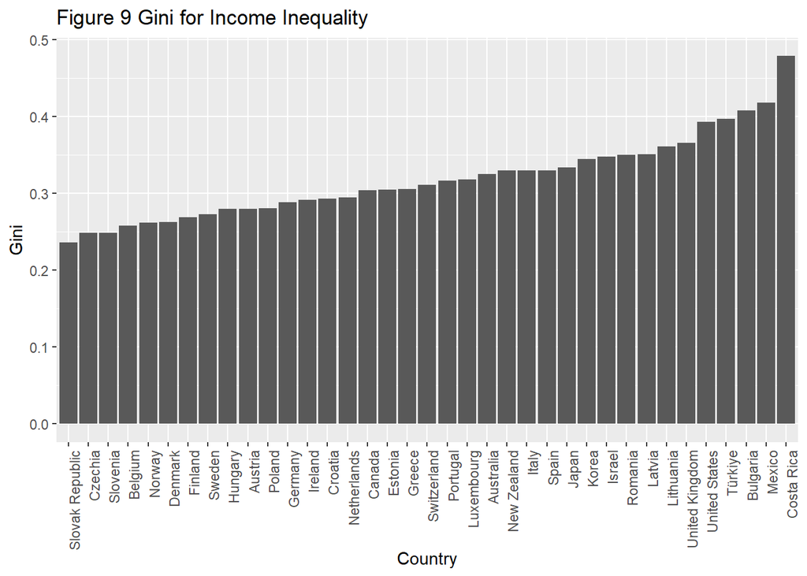

The Gini coefficient is commonly used as a measure of inequality within a population. It aims to quantify the inequality of income distribution in the sample on a range from 0 to 1, where 0 means everyone receives the same income and 1 means one person has all the income. This scale allows for comparison across countries.

Does a relationship between income inequality and the structure of tertiary education spending exist? It may be proposed that increased public investment in education decreases income inequality through the increasing of education accessibility particularly to lower income groups. The same may be true for increases in private spending on education increasing inequality by restricting access for lower income groups. This relationship will first be investigated using a simple linear model, followed by a panel model with fixed and random effects.

The linear model in Figure 10 suggests a positive relationship between the ratio of private to public education spending and a higher Gini coefficient. This supports the aforementioned hypothesis that increased private education spending (or decreased government spending) is related to a higher Gini coefficient and therefore higher inequality within the population.

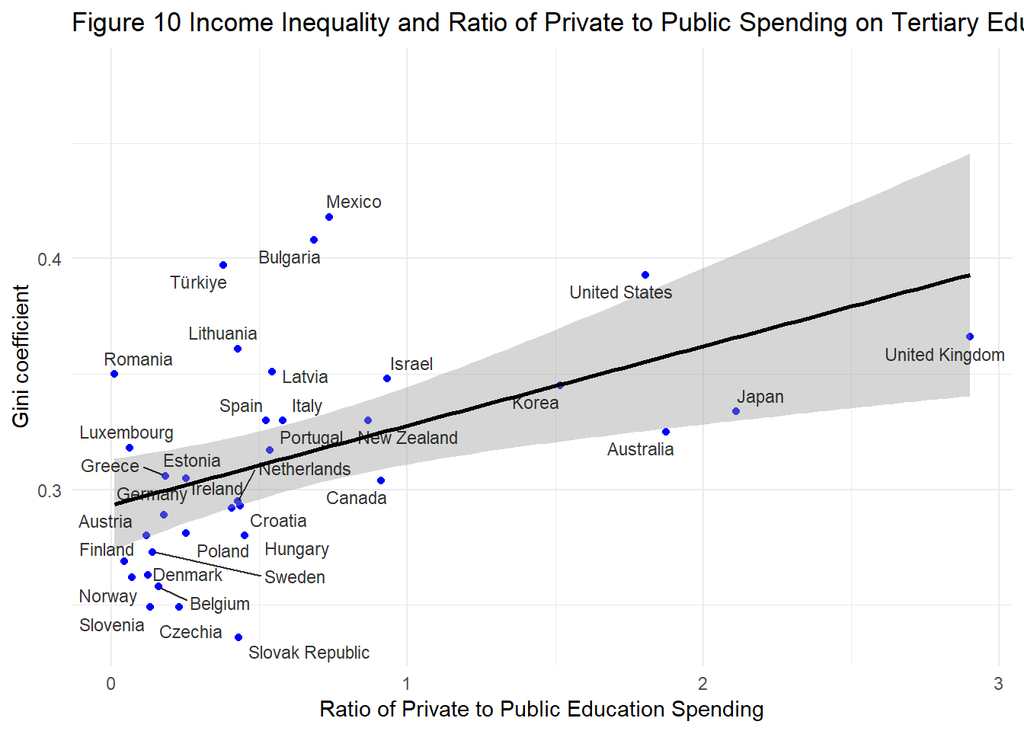

Investigating this more closely we obtain the following results of the model

```
##
## Call:
## lm(formula = merged_gini_edu$gini ~ merged_gini_edu$Ratio)
##
## Residuals:
##      Min       1Q   Median       3Q      Max
## -0.07217 -0.02795 -0.01307  0.02058  0.09927
##
## Coefficients:
##                       Estimate Std. Error t value Pr(>|t|)
## (Intercept)           0.293451   0.009705  30.238  < 2e-16 ***
## merged_gini_edu$Ratio 0.034296   0.010813   3.172  0.00327 **
## ---
## Signif. codes:  0 '***' 0.001 '**' 0.01 '*' 0.05 '.' 0.1 ' ' 1
##
## Residual standard error: 0.04202 on 33 degrees of freedom
##   (2 observations deleted due to missingness)
## Multiple R-squared:  0.2336, Adjusted R-squared:  0.2104
## F-statistic: 10.06 on 1 and 33 DF,  p-value: 0.003267
```

For further investigation, a panel data regression model with control variables for GDP per capita and the unemployment rate. Both the fixed effects model and the random effects model are tested and compared with the Hausman test to determine whether individual effects are correlated with the independent variables. The model is defined as:
$$\begin{equation}
\text{Gini}_{i,t} = \alpha_i + \beta_1 (\text{Private/Public
Ratio}_{i,t}) + \beta_2 (\text{GDP per capita}_{i,t}) + \beta_3
(\text{Unemployment rate}_{i,t}) + \epsilon_{i,t}
\end{equation}$$

Where $i$ represents the country, $t$ represents the time period, $\alpha$ represents the country-specific intercepts (fixed effects), $\beta_1$ is the coefficient for the ratio of private to public funding, $\beta_2$ is the coefficient for GDP per capita, $\beta_3$ is the coefficient for the unemployment rate and $\epsilon_{i,t}$ is the error term.

The results from the three tests are as follows:

```
## Oneway (individual) effect Within Model
##
## Call:
## plm(formula = model_formula, data = panel_data, model = "within")
##
## Unbalanced Panel: n = 37, T = 1-16, N = 357
##
## Residuals:
##       Min.    1st Qu.     Median    3rd Qu.       Max.
## -0.0467153 -0.0053225  0.0000000  0.0051350  0.0482159
##
## Coefficients:
##                      Estimate  Std. Error t-value Pr(>|t|)
## Ratio              1.9144e-03  2.5684e-03  0.7454   0.4566
## gdp_pcap_data     -2.1729e-07  1.3306e-07 -1.6330   0.1035
## unemployment_rate  3.9854e-04  2.6717e-04  1.4917   0.1368
##
## Total Sum of Squares:    0.045533
## Residual Sum of Squares: 0.044375
## R-Squared:      0.025435
## Adj. R-Squared: -0.094465
## F-statistic: 2.75772 on 3 and 317 DF, p-value: 0.042437
```

```
## Oneway (individual) effect Random Effect Model
##    (Swamy-Arora's transformation)
##
## Call:
## plm(formula = model_formula, data = panel_data, model = "random")
##
## Unbalanced Panel: n = 37, T = 1-16, N = 357
##
## Effects:
##                    var  std.dev share
## idiosyncratic 0.000140 0.011832 0.086
## individual    0.001495 0.038663 0.914
## theta:
##    Min. 1st Qu.  Median    Mean 3rd Qu.    Max.
##  0.7074  0.8985  0.9154  0.9052  0.9185  0.9237
##
## Residuals:
##      Min.   1st Qu.    Median      Mean   3rd Qu.      Max.
## -0.053254 -0.006313 -0.001868 -0.000458  0.005415  0.045577
##
## Coefficients:
##                      Estimate  Std. Error z-value Pr(>|z|)
## (Intercept)        3.3022e-01  9.1378e-03 36.1373  < 2e-16 ***
## Ratio              4.8052e-03  2.6189e-03  1.8349  0.06653 .
## gdp_pcap_data     -3.5330e-07  1.2847e-07 -2.7500  0.00596 **
## unemployment_rate  3.5194e-04  2.7786e-04  1.2666  0.20529
## ---
## Signif. codes:  0 '***' 0.001 '**' 0.01 '*' 0.05 '.' 0.1 ' ' 1
##
## Total Sum of Squares:    0.088994
## Residual Sum of Squares: 0.055178
## R-Squared:      0.39263
## Adj. R-Squared: 0.38747
## Chisq: 17.0471 on 3 DF, p-value: 0.00069115
```

```
##
##  Hausman Test
##
## data:  model_formula
## chisq = 9.0566, df = 3, p-value = 0.02855
## alternative hypothesis: one model is inconsistent
```

The fixed effects model find no significant relationship between the private and public funding ratio, GDP per capita, or unemployment rate with the Gini coefficient. The random effects model finds a somewhat significant effect of the funding ratio on the Gini coefficient (at 10% level), a statistically significant effect for GDP per capita (at 1% level), and no significant effect of unemployment rate. While the random effect tests seems to have more explanatory power than the fixed effects model, the Hausman test has found a significant result, meaning there likely exists correlation of individual effects between the independent variables, meaning the fixed effect model should be used.

# 6 Relationship with Happiness

Does the ratio of private to public spending on tertiary education effect the happiness level of a country? While this may be a novel question, it would be interesting to investigate if there is a relationship and ponder the method of which it may eventuate. Perhaps increasing public funding allows citizens to pursue studies for self fulfillment, rather than simply economic reasons?

[interactive chart not shown]

Recalling the Figure 1, the map depicting the mean years schooling for each country, this map of happiness scores might suggest a correlation. To investigate this, another simple linear regression is employed. The results are as follows:

```
##
## Call:
## lm(formula = merged_happy_edu$Ladder.score ~ merged_happy_edu$Ratio)
##
## Residuals:
##      Min       1Q   Median       3Q      Max
## -1.68149 -0.34443  0.04415  0.43384  1.02677
##
## Coefficients:
##                        Estimate Std. Error t value Pr(>|t|)
## (Intercept)              6.7214     0.1331  50.494   <2e-16 ***
## merged_happy_edu$Ratio  -0.1719     0.1468  -1.172    0.249
## ---
## Signif. codes:  0 '***' 0.001 '**' 0.01 '*' 0.05 '.' 0.1 ' ' 1
##
## Residual standard error: 0.5987 on 37 degrees of freedom
##   (10 observations deleted due to missingness)
## Multiple R-squared:  0.03577,    Adjusted R-squared:  0.009706
## F-statistic: 1.372 on 1 and 37 DF,  p-value: 0.2489
```

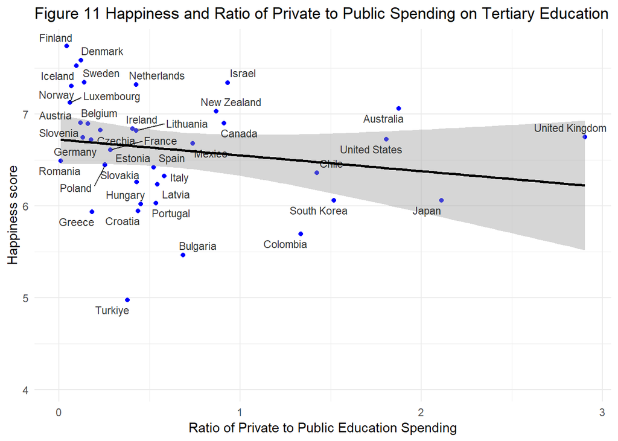

The regression results indicate a coefficient of -0.1719 for the ratio variable, although this coefficient is not statistically significant (p-value = 0.2489). This suggests that any relationship between these two variables is inconclusive. Furthermore, the regression’s adjusted R-squared value of 0.0097 indicates that only a negligible proportion of the variance in happiness scores can be explained by variations in the ratio of educational spending types across countries.

In Figure 11, the scatter plot visually represents the relationship between happiness scores and the ratio of private to public spending on tertiary education. It is clear that the relationship is ambiguous if existent. This suggests that the structuring of tertiary education does not affect the happiness score of a country.

# 7 Education Funding and University Ranking

As a final investigation for the impacts of the structure of education funding, another fixed effects panel data model can be used. This analysis investigates the impact of GDP, public education funding, and private education funding on university rankings as measured by the Times Higher Education (THE) rankings. Using panel data from 36 countries over a period of up to 11 years, the fixed effects model was used to account for individual heterogeneity.

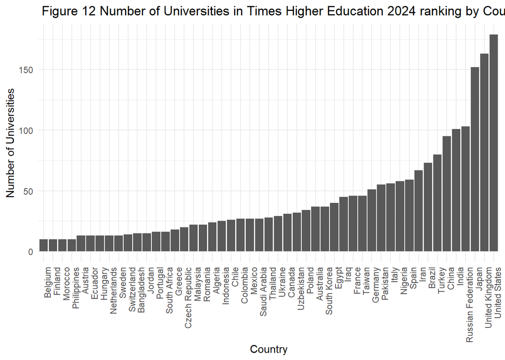

```
## Oneway (individual) effect Within Model
##
## Call:
## plm(formula = rank ~ gdp_usd + public_funding + private_funding,
##     data = pdata, model = "within")
##
## Unbalanced Panel: n = 36, T = 1-11, N = 287
##
## Residuals:
##      Min.   1st Qu.    Median   3rd Qu.      Max.
## -440.2527  -67.7876    1.7725   51.6313  603.6760
##
## Coefficients:
##                    Estimate  Std. Error t-value Pr(>|t|)
## gdp_usd         -5.8915e-04  2.2643e-03 -0.2602  0.79493
## public_funding  -2.9507e+02  1.2986e+02 -2.2722  0.02393 *
## private_funding  6.9336e+01  1.3345e+02  0.5196  0.60384
## ---
## Signif. codes:  0 '***' 0.001 '**' 0.01 '*' 0.05 '.' 0.1 ' ' 1
##
## Total Sum of Squares:    6927600
## Residual Sum of Squares: 6753000
## R-Squared:      0.025192
## Adj. R-Squared: -0.12417
## F-statistic: 2.13634 on 3 and 248 DF, p-value: 0.096178
```

# 8 Conclusion

Since 1990, the world mean years of schooling have increased, indicating a global trend towards higher educational attainment. A continuum of funding ratios between public and private tertiary education expenditures exists, with some countries relying solely on government funding and others predominantly on private funding. A positive linear relationship between GNI/GDP per capita and total tertiary education spending per capita was identified, although this relationship does not extend to the ratio of private to public funding. There is also a positive relationship between the ratio of private to public education spending and the Gini coefficient for income inequality, but this does not hold in a panel regression with fixed effects, which was validated as the appropriate model. Additionally, no significant effect of funding ratios on the happiness scores of countries was found, and there is potentially a small significant negative effect of public funding on the Times Higher Education university rankings. These findings shed a little insight between tertiary education funding, economic factors, and social outcomes, suggesting that while increased funding correlates with higher educational attainment and economic wealth, the source of funding may not have significant effects on macroeconomic outcomes.

Anon., 2023, [World University Rankings](https://www.timeshighereducation.com/world-university-rankings/2024/world-ranking), *Times Higher Education (THE)*.

Anon., [United Nations Development Programme](https://report.hdr.undp.org/?_gl=1*w0o1dw*_ga*MTEyMzE3MTU4OS4xNzE4MDk5ODU0*_ga_3W7LPK0WP1*MTcxOTE3NjQ2NS42LjEuMTcxOTE3NjQ3OC40Ny4wLjA.),.

Anon., [THE World University Rankings 2011-2024](https://www.kaggle.com/datasets/r1chardson/the-world-university-rankings-2011-2023),.

Anon., OECD Data Explorer • Income distribution database,.

Arel-Bundock, Vincent, 2022, *[WDI: World Development Indicators and Other World Bank Data](https://CRAN.R-project.org/package=WDI)*.

Helliwell, John F., Richard Layard, Jeffrey D. Sachs, Jan-Emmanuel De Neve, Lara B. Aknin, and Shun Wang, 2024, *[World Happiness Report 2024](https://worldhappiness.report/ed/2024/)*.

OECD, 2023, *[Education at a Glance 2023: OECD Indicators](https://www.oecd-ilibrary.org/education/education-at-a-glance-2023_e13bef63-en)* (Organisation for Economic Co-operation; Development, Paris).